# Encuesta sobre hábitos de estudio 3

Zuleima carriazo

Miércoles, 16 de septiembre de 2020

# Analisis descriptivo y exploratoria de la incuenta habitos.

## Depuración de la variable Carrera, dentro de la asignatura en la cual se hizo esta encuesta

Se encuentra en la base de datos original diferentes formas de nombrar una misma carrera, así que se hace la compilacion de los datos y enseguida colapsaremos a un solo nombre que representa de manera ideal todas las anteriores formas en que fueron escritas, creando una nueva columna con el nombre correcto para cada una.

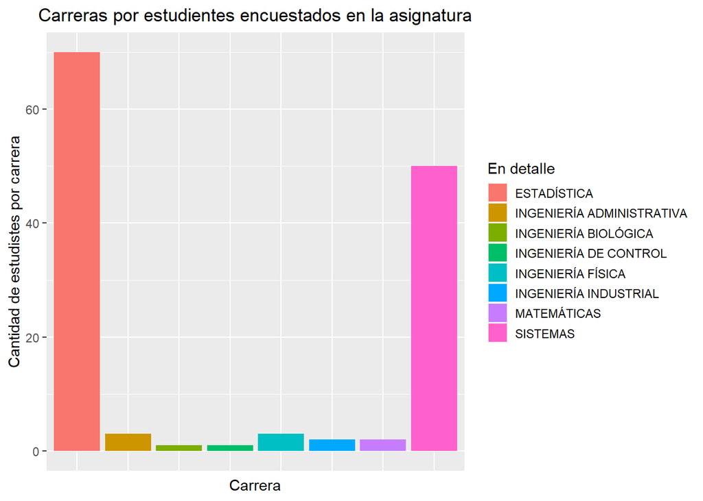

## Depuración y analisis descriptivo de la variable genero

```
##  chr [1:132] "Masculino" "Masculino" "Masculino" "Femenino" "Masculino" ...
```

Los resultados que obtenimos al realizar la depuracion y la descripcion de la variable genero, son los siguientes; segun los datos generados por la incuesta habitos notamos que la mayoria de los estudinates son de genero masculino, como lo podemos notar en la siguiente grafica.

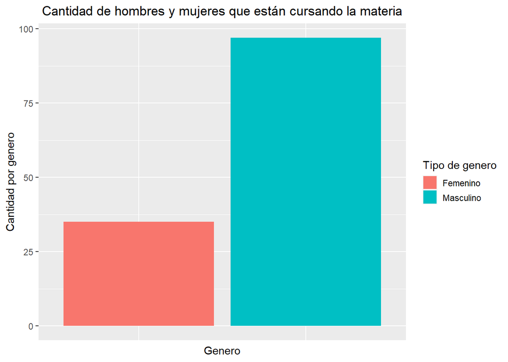

## Analisis y depuracion de la variable fecha de nacimiento

Acontinuación exploramos la variable fecha de nacimiento y la sustituimos por la variable artificial año, en la primera, encontramos algunas inconsistencias, asi que se quitaron las dos fechas mencionadas también se eliminó dos datos que se consideraron incorrectos, que son 1956, 1977, ya que es casi imposible que tenga esa edad y este estudiando ese curso, es decir que tenemos un compañero o compañera de 64 o 43 años de edad es difícil de creer, optamos por retirar dichos datos ya que nos es difícil pensar que compartimos salón de clases o en este caso virtualidad con alguien de tanta edad, además nos es difícil investigar y no tenemos la oportunidad de observar el físico de la persona de forma presencial para afirmar que compartimos en el curso con alguien de esas características, dichas 2 observaciones no se remplazan por el promedio porque son solo dos y no afecta mucho a las 132. Hubo un dato donde aparecía un signo de exclamación en este dato se infirió que pudo haber un error de digitación, entonces se puso un 1.

Se tomó la decisión de omitir los NA ya que no hacen una gran representación. Se toma la decisión de hacer 2 gráficas para que quedara cómodo para visualizar por parte del lector, decimos esto en el sentido de que el lector pueda observar unas dimensiones aceptables, por eso en una gráfica tenemos los datos de 0 a máximo 5 personas nacidas en los años 1982, 1983, 1987, 1989, 1992, 1993, 1994, 1997 y en la otra grafica tenemos los datos que van de 0 a 30 estudiantes nacidos en los años 1995, 1996, 1998, 1999, 2000, 2001, 2002, 2003. las muestras nos arrojan resultados como que 75 estudiantes nacieron después del año 2000, es decir más de la mitad de estudiantes tienen menos de 20 años, 51 personas nacieron entre los años 1990 y 1999 y por ultimo tendríamos que 4 personas nacieron entre 1980 y 1989.

```
##  chr [1:130] "2000" "1999" "2001" "2000" "2002" "2000" "1999" "2000" "2000" ...
```

## grafica uno

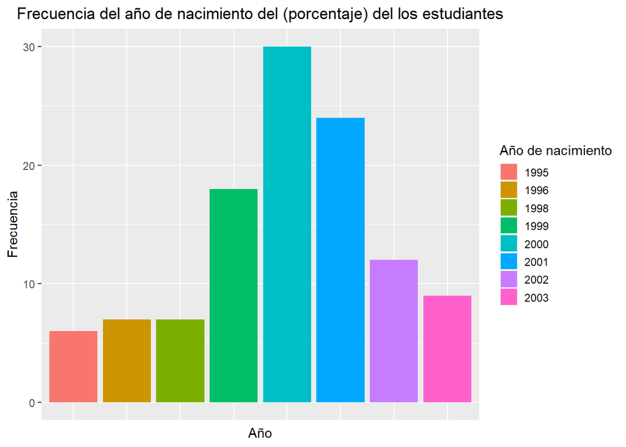

## grafica dos

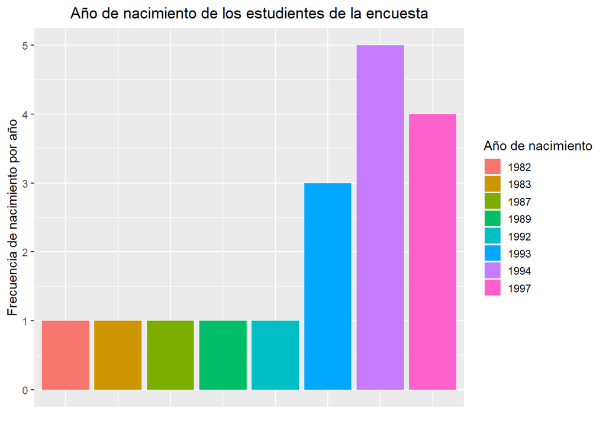

# Analisis descriptivo y exploratorio de la variable PAPA

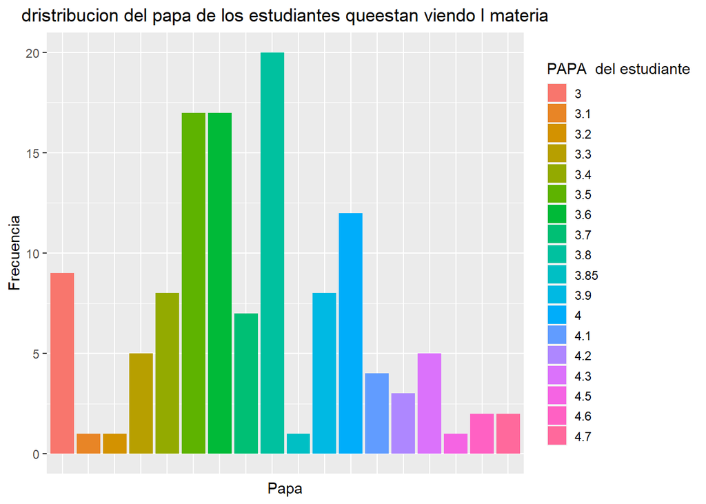

## Analisis descriptivo y exploratorio de la variable estrato.

La variable estrato es categórica y cabe mencionar el gran número de estudiantes que se concentrar en estratos 2 y 3, 96 estudiantes se ubican en estos 2 estratos representando casi el 75% de la población en el muestreo, también es bueno resaltar que tenemos de a 1 compañero en los extremos de la observación, tanto en el estrato 0 como en el 5, cmo se puede observar en al siguinte grafica

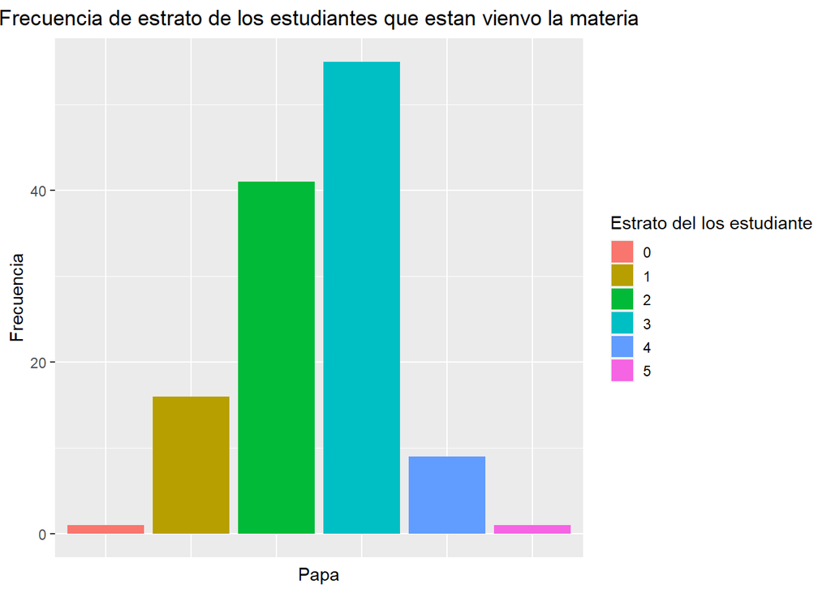

## Analisis descritivo y exploratorio de la variable computado_mesa.

Esta variable es de tipo discreta, no requirio de una depuracion, ya que lo dados encontrados en la tabal se encontraban en un buen estado para poder trabajar sobre ellos, lo reslutados optenidos lo podemos visulizar en la siguinte grafica. En ella podmeos notar que la mayoria de los estudiantes no tienen computador de mesa, suponemos que se debe a que tiene es computadora portatil. Como dados curiosos encotramos que hay estudiantes que tiene pero de manera alquilada o prestada, una posible causa de ello puede ser los bajos recursos que puede presentar la persona, o un daño en la computadora de ella(o).

[figure not shown]

# Analisis descritivo y exploratorio de la variable portatil.

Esta variable categórica va mostrando como los estudiantes van cambiando sus herramientas de trabajo, por otras mas cómodas para sus estrategía de estudio, estos nos lleva a pensar que puede deberse a la practicidad que proporciona los diferentes tipos de tecnologia actual, frente a tecnologias que bien, pueden cumplir en todo su función pero ya o serían faciles de manejar, y/o refiriendonos a que de computador de mesa muchos de los compañeros anotaron que no cuentan con éste, y de los pacos que portatil.

En la gráfica de la variable categórica portátiles podemos encontrar que cerca del 75% de los estudiantes matriculados en el curso posee computador portátil y propio lo que facilita que se atienda a las actividades del curso, podemos decir también que más del 75 % de los alumnos posee computador portátil lo que muestra que la gran mayoría de los estudiantes estamos conectados, podríamos preguntarnos si tienen computador portátil y de mesa o solamente portátil, podríamos preguntarnos si los 16 estudiantes que dicen no tener portátil tienen computador de mesa o si en verdad no disponen de computador para atender a las clases y actividades del curso, cabe resaltar que al menos 15 estudiantes si tienen portátil pero no es de ellos propiamente según esta información surgirían dudas sobre si deben compartir el computador, si tienen inconvenientes en la entrega de los talleres por el hecho que tal vez algún familiar ocupe el dispositivo electrónico o cosas por el estilo

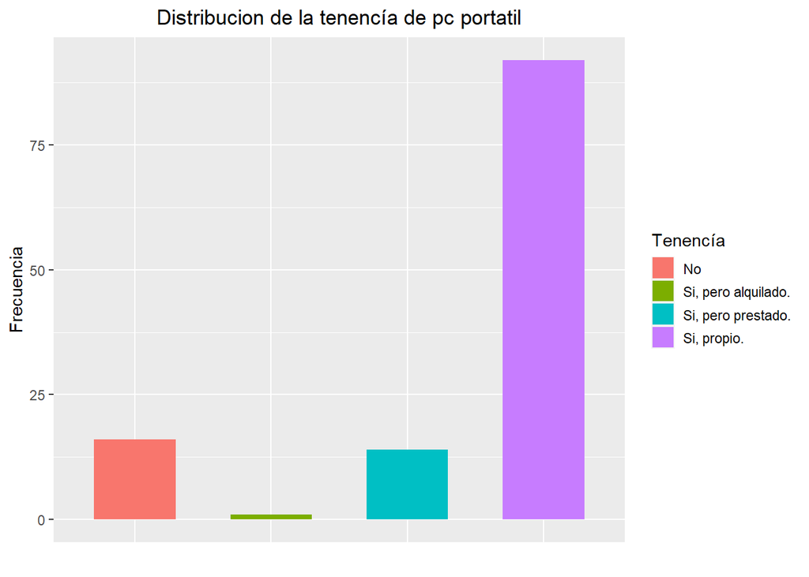

# Analisis descriptivo y exploratorio de la variable smartphone.

Esta variable no se le realizo ningun tipo de depuracion ya que se encontraba en un buen estado para trabajar sobre ella. Los resultados son los esperados, que la mayor parte de los estudiantes tegan celular inteligente, tambien encontramos como dato curiosos o que se incuentra personas que tienen celular alquilado o que no tienen, es de sorprederse debido a la era digital que stamos viviendo, suponemos ques e debe a algun daños del celular inteligen de la persona y es por ello que tiene uno prestado o alquilado. Estos resultados los podemos notar o visualizar en la siguinte grafica.

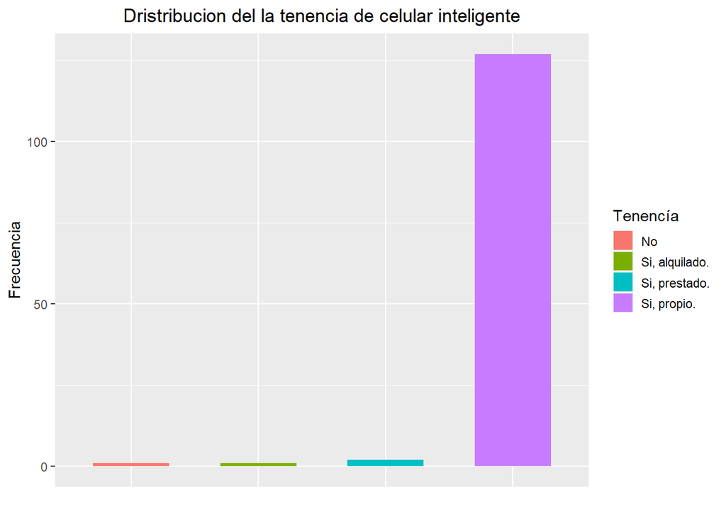

## Analisis descriptico y exploratorio de la variable origen_covid_19

Esta variable se encontro en buen estado, por lo tanto no requierio de una depuracion, por lo que se continuo a hacer una estadistica descriptiva, y los resultados optenidos los podemos notar en la siguiente grafica, en ella podemos notar que la hipotesis con mas fuerza es; fue resultado de pasar el virus de los animales a los humanos, seguida por, Fue fabricado en un laboratorio.

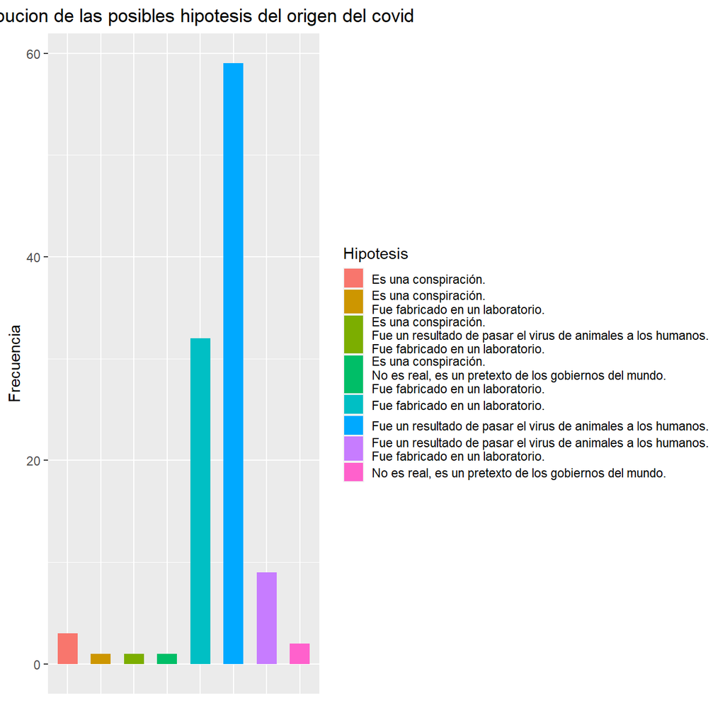

## Analisis descriptico y exploratorio de la variable esta_gov

Estadisticas del gobierno y la creencia que tienen los estudiantes acerca de su veracidad Se explora esta variable y se encuentra algunos espacios vacios, se concluye que aunque anonimizada la encuesta, algunos estudiantes prefieren no opinar acerca del tema, no responden.

Es interesante notar que los resultados de esta gráfica muestre tal magnitud de desconfianza hacia este tema, esto podría deberse a recientes visualizacones de graficas que no corresponden en programas de la television Colombiana. Esto lo podemos visualizar en la siguiente grafica.

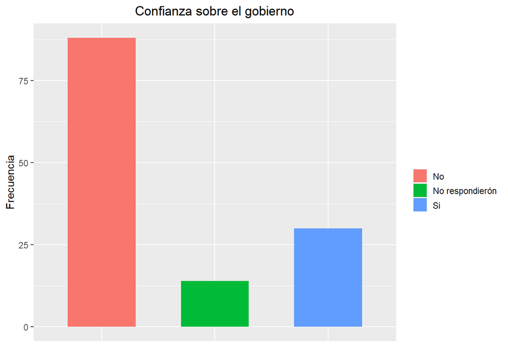

# Analisis descriptivo y exploratorio de los habitos

[figure not shown]

[figure not shown]

[figure not shown]